# Building a Predictive Model for the Weight Lifting Exercise Dataset

Vasilena Taralova

December 18, 2016

# 1 Introduction

In this project we build a *predictive model* for a weight lifting exercise dataset. The data is collected from acceleration and position sensors put on the belt, forearm, arm, and dumbell of 6 participants. The participants were asked to perform barbell lifts correctly and incorrectly in 5 different ways. The correctly performed exercises are labeled as class A in the dataset and the various incorrectly performed exercises are labeled as classes B to E depending on the mistakes made. The labels are stored in the “classe” variable. The full data can be downloaded from the University of California, Irvine (UCI) [Machine Learning Repository](https://archive.ics.uci.edu/ml/datasets/Weight+Lifting+Exercises+monitored+with+Inertial+Measurement+Units). The analysis in the project is performed on a preprocessed version of the dataset as part of the Practical Machine Learning course by Johns Hopkins University on Coursera. While the filtered dataset is not publicly available, it uses data only from the original dataset. More information about the Weight Lifting Exercise Dataset is available at: http://groupware.les.inf.puc-rio.br/har#ixzz4TBbNIRh9 , as well as in the paper: “Qualitative Activity Recognition of Weight Lifting Exercises”, Velloso, E., Bulling, A., Gellersen, H., Ugulino, W. and Fuks, H., Proceedings of 4th International Conference in Cooperation with SIGCHI (Augmented Human ’13), Stuttgart, Germany: ACM SIGCHI, 2013.

Our goal is, based on the given measurements, *to build a model that can predict whether an exercise is performed correctly or not for new data*. We use Random Forest and Support Vector Machines (SVM) algorithms to build prediction models. We then compare the two models in terms of their prediction accuracy on a test dataset, i.e. new data.

# 2 Reading the data

First we load the packages that we will need:

```r
library(caret)
library(e1071)
library(randomForest)
```

Then we set the working directory:

```r
setwd("D:/Coursera_Practical_Machine_Learning/Final_Project")
```

Since the dataset that we use is not publicly available, we do not include the code for downloading the coma-separated-value files that we read below:

```r
db.train = read.table("pml-training.csv", sep = ",", header = TRUE)

db.test = read.table("pml-testing.csv", sep = ",", header = TRUE)
```

In the “db.train” data frame we store the train dataset and in the “db.test” data frame – the test dataset.

The data frame “db.train” has 19622 observations of 160 variables:

```r
dim(db.train)
```

```
[1] 19622   160
```

and the “db.test” data frame has 20 rows and 160 columns:

```r
dim(db.test)
```

```
[1]  20 160
```

Let us take a look at part of the “db.train” data frame:

```r
head(db.train[ , 1:12])
```

```
  X user_name raw_timestamp_part_1 raw_timestamp_part_2   cvtd_timestamp
1 1  carlitos           1323084231               788290 05/12/2011 11:23
2 2  carlitos           1323084231               808298 05/12/2011 11:23
3 3  carlitos           1323084231               820366 05/12/2011 11:23
4 4  carlitos           1323084232               120339 05/12/2011 11:23
5 5  carlitos           1323084232               196328 05/12/2011 11:23
6 6  carlitos           1323084232               304277 05/12/2011 11:23
  new_window num_window roll_belt pitch_belt yaw_belt total_accel_belt
1         no         11      1.41       8.07    -94.4                3
2         no         11      1.41       8.07    -94.4                3
3         no         11      1.42       8.07    -94.4                3
4         no         12      1.48       8.05    -94.4                3
5         no         12      1.48       8.07    -94.4                3
6         no         12      1.45       8.06    -94.4                3
  kurtosis_roll_belt
1
2
3
4
5
6
```

The labels which indicate whether or not an exercise is performed correctly are stored in the factor variable “classe”:

```r
head(db.train$classe, 15)
```

```
 [1] A A A A A A A A A A A A A A A
Levels: A B C D E
```

# 3 Cleaning missing values

First we check for the percentage of missing values in each variable. For this purpose we create a list containing the columns of the data frame “db.train”:

```r
db.columns.list <- as.list(db.train)
```

Then we use the R function “sapply()” from the base installation to create the numeric vectors “sum.NA” and “percentage.NA” which contain the number and percentage of NA values for each of the 160 variables:

```r
sum.NA <- sapply(db.columns.list, function(v){

  sum(is.na(v))

}, simplify = TRUE)

percentage.NA <- sapply(db.columns.list, function(v){

  round(100*mean(is.na(v)), 3)

}, simplify = TRUE)
```

It turns out that the number of variables with missing values is 67:

```r
length(which(sum.NA > 0))
```

```
[1] 67
```

Next, we extract the indices of the variables with missing values and we display the names of these variables along with the respective percentage of NA values:

```r
indices.NA <- which(sum.NA > 0)

percentage.NA[indices.NA]
```

```
           max_roll_belt           max_picth_belt            min_roll_belt
                  97.931                   97.931                   97.931
          min_pitch_belt      amplitude_roll_belt     amplitude_pitch_belt
                  97.931                   97.931                   97.931
    var_total_accel_belt            avg_roll_belt         stddev_roll_belt
                  97.931                   97.931                   97.931
           var_roll_belt           avg_pitch_belt        stddev_pitch_belt
                  97.931                   97.931                   97.931
          var_pitch_belt             avg_yaw_belt          stddev_yaw_belt
                  97.931                   97.931                   97.931
            var_yaw_belt            var_accel_arm             avg_roll_arm
                  97.931                   97.931                   97.931
         stddev_roll_arm             var_roll_arm            avg_pitch_arm
                  97.931                   97.931                   97.931
        stddev_pitch_arm            var_pitch_arm              avg_yaw_arm
                  97.931                   97.931                   97.931
          stddev_yaw_arm              var_yaw_arm             max_roll_arm
                  97.931                   97.931                   97.931
           max_picth_arm              max_yaw_arm             min_roll_arm
                  97.931                   97.931                   97.931
           min_pitch_arm              min_yaw_arm       amplitude_roll_arm
                  97.931                   97.931                   97.931
     amplitude_pitch_arm        amplitude_yaw_arm        max_roll_dumbbell
                  97.931                   97.931                   97.931
      max_picth_dumbbell        min_roll_dumbbell       min_pitch_dumbbell
                  97.931                   97.931                   97.931
 amplitude_roll_dumbbell amplitude_pitch_dumbbell       var_accel_dumbbell
                  97.931                   97.931                   97.931
       avg_roll_dumbbell     stddev_roll_dumbbell        var_roll_dumbbell
                  97.931                   97.931                   97.931
      avg_pitch_dumbbell    stddev_pitch_dumbbell       var_pitch_dumbbell
                  97.931                   97.931                   97.931
        avg_yaw_dumbbell      stddev_yaw_dumbbell         var_yaw_dumbbell
                  97.931                   97.931                   97.931
        max_roll_forearm        max_picth_forearm         min_roll_forearm
                  97.931                   97.931                   97.931
       min_pitch_forearm   amplitude_roll_forearm  amplitude_pitch_forearm
                  97.931                   97.931                   97.931
       var_accel_forearm         avg_roll_forearm      stddev_roll_forearm
                  97.931                   97.931                   97.931
        var_roll_forearm        avg_pitch_forearm     stddev_pitch_forearm
                  97.931                   97.931                   97.931
       var_pitch_forearm          avg_yaw_forearm       stddev_yaw_forearm
                  97.931                   97.931                   97.931
         var_yaw_forearm
                  97.931
```

All of the variables with non-zero number of NA values have more than 90% missing values:

```r
length(which(percentage.NA[indices.NA] > 0.9))==length(which(sum.NA > 0))
```

```
[1] TRUE
```

Looking at the data frame we notice that there are also many variables containing nonsense values, such as “” (empty fields) and “#DIV/0!”, e.g.:

```r
head(db.train[, 70:75], 10)
```

```
   kurtosis_picth_arm kurtosis_yaw_arm skewness_roll_arm
1
2
3
4
5
6
7
8
9
10
   skewness_pitch_arm skewness_yaw_arm max_roll_arm
1                                                NA
2                                                NA
3                                                NA
4                                                NA
5                                                NA
6                                                NA
7                                                NA
8                                                NA
9                                                NA
10                                               NA
```

We investigate these variables and we remove them. We create the vectors “number.nomeaning” and “percentage.NM” containing respectively the number and percentage of “” or “#DIV/0!” values for each variable in the training data set:

```r
number.nomeaning <- sapply(db.columns.list, function(v){

  sum(v == "" | v == "#DIV/0!")

}, simplify = TRUE)


percentage.NM <- sapply(db.columns.list, function(v){

  round(100*mean(v == "" | v == "#DIV/0!"), 3)

}, simplify = TRUE)
```

The number of variables with “” or “#DIV/0!” values is:

```r
length(which(number.nomeaning > 0))
```

```
[1] 33
```

Below we show the variables containing non-meaningful values together with the respective percentage of these values:

```r
indices.NM <- which(number.nomeaning > 0)

percentage.NM[indices.NM]
```

```
     kurtosis_roll_belt     kurtosis_picth_belt       kurtosis_yaw_belt
                 97.982                  98.094                 100.000
     skewness_roll_belt    skewness_roll_belt.1       skewness_yaw_belt
                 97.977                  98.094                 100.000
           max_yaw_belt            min_yaw_belt      amplitude_yaw_belt
                 97.982                  97.982                  97.982
      kurtosis_roll_arm      kurtosis_picth_arm        kurtosis_yaw_arm
                 98.328                  98.339                  97.987
      skewness_roll_arm      skewness_pitch_arm        skewness_yaw_arm
                 98.323                  98.339                  97.987
 kurtosis_roll_dumbbell kurtosis_picth_dumbbell   kurtosis_yaw_dumbbell
                 97.956                  97.941                 100.000
 skewness_roll_dumbbell skewness_pitch_dumbbell   skewness_yaw_dumbbell
                 97.951                  97.936                 100.000
       max_yaw_dumbbell        min_yaw_dumbbell  amplitude_yaw_dumbbell
                 97.956                  97.956                  97.956
  kurtosis_roll_forearm  kurtosis_picth_forearm    kurtosis_yaw_forearm
                 98.359                  98.364                 100.000
  skewness_roll_forearm  skewness_pitch_forearm    skewness_yaw_forearm
                 98.354                  98.364                 100.000
        max_yaw_forearm         min_yaw_forearm   amplitude_yaw_forearm
                 98.359                  98.359                  98.359
```

All of the variables with non-zero number of non-meaningful values have more than 90% of these non-meaningful values:

```r
length(which(percentage.NM[indices.NM] > 0.9))==length(which(number.nomeaning > 0))
```

```
[1] TRUE
```

We check if there is an overlap between the variables containig missing values (NA) and the variables containing non-meaningful values:

```r
intersect(indices.NM, indices.NA)
```

```
integer(0)
```

It turns out there is no overlap between the two sets of variables.

Now we remove from the data frame all variables containing missing or non-meaningful values:

```r
both.indices <- c(indices.NA, indices.NM)

db.train <- db.train[, -both.indices]

db.test <- db.test[, -both.indices]
```

We removed a total of 100 variables:

```r
length(both.indices)
```

```
## [1] 100
```

Further, we exclude also the variables “X”, “user_name”, “raw_timestamp_part_1”, “raw_timestamp_part_2”, “cvtd_timestamp”, “new_window” and “num_window” (the first seven columns from the data frame), because we do not need them to predict whether or not an exercise is done correctly:

```r
ind <- c(1:7) # the indices of the columns we want to remove

db.train = db.train[,-ind]

db.test = db.test[,-ind]
```

# 4 Partition of the “db.train” data set into a new training set and a validation set

We partition the training dataset into a new training dataset and a cross validation dataset. We use 70% of the training dataset for the new training data and the other 30% – for cross validation:

```r
set.seed(35721)

inTrain = createDataPartition(y = db.train$classe, p = 0.7, list = FALSE)

db.training = db.train[inTrain, ]

db.validation = db.train[-inTrain, ]
```

The dimensions of the new datasets are given below:

```r
dim(db.training)
```

```
[1] 13737    53
```

```r
dim(db.validation)
```

```
[1] 5885   53
```

# 5 Fitting a prediction model

We build a model that can predict whether an exercise is performed correctly or not for new observations. We use Random Forest and Support Vector Machines (SVM) algorithms to build the prediction models.

## 5.1 Support Vector Machines

We fit a model with the Support Vector Machines (SVM) algorithm, which is implemented in the R package “e1071”. This is a popular method that usually has reasonable default performance and has parameters that allow for further tuning if necessary. It also allows for fitting both linearly and non-linearly separable data using linear or non-linear kernels, respectively. By default, the “svm()” function in the “e1071” package scales the data.

### 5.1.1 Linear kernel

First we train an SVM model with kernel set to “linear”:

```r
set.seed(45112)

start_time <- proc.time()
ModSVM.lin <- svm(formula = classe~.,
                  data = db.training,
                  kernel = "linear")
time <- proc.time() - start_time
time
```

```
##    user  system elapsed
##   44.86    0.28   45.32
```

The computational time is approximately 44.86s.

The vector “predSVM.lin” contains the predictions on the training data set:

```r
predSVM.lin <- predict(object = ModSVM.lin,
                       newdata = db.training)
```

The “ModSVM.lin” model predicts about 78.998% of the “classe” variable on the training data:

```r
mean(predSVM.lin == db.training$classe)
```

```
[1] 0.7899833
```

Below we show the confusion matrix and some other statistics for the predicted outcome (the “classe” variable) on the training set:

```r
confusionMatrix(data = predSVM.lin,
                reference = db.training$classe)
```

```
Confusion Matrix and Statistics

          Reference
Prediction    A    B    C    D    E
         A 3596  344  194  136  128
         B   82 1904  197   93  305
         C   98  167 1878  252  165
         D  117   49   63 1672  125
         E   13  194   64   99 1802

Overall Statistics

               Accuracy : 0.79
                 95% CI : (0.7831, 0.7968)
    No Information Rate : 0.2843
    P-Value [Acc > NIR] : < 2.2e-16

                  Kappa : 0.7331
 Mcnemar's Test P-Value : < 2.2e-16

Statistics by Class:

                     Class: A Class: B Class: C Class: D Class: E
Sensitivity            0.9206   0.7163   0.7838   0.7425   0.7137
Specificity            0.9184   0.9389   0.9399   0.9692   0.9670
Pos Pred Value         0.8176   0.7377   0.7336   0.8253   0.8297
Neg Pred Value         0.9668   0.9324   0.9537   0.9505   0.9375
Prevalence             0.2843   0.1935   0.1744   0.1639   0.1838
Detection Rate         0.2618   0.1386   0.1367   0.1217   0.1312
Detection Prevalence   0.3202   0.1879   0.1864   0.1475   0.1581
Balanced Accuracy      0.9195   0.8276   0.8618   0.8558   0.8403
```

The vector “predSVM.valid.lin” contains the predictions on the validation data set:

```r
predSVM.valid.lin <- predict(object = ModSVM.lin,
                             newdata = db.validation)
```

As we can see, the accuracy on the validation set is 78.794%. As expected, the “out of sample” accuracy is less than the “in sample” accuracy (and respectively, the “out of sample” error is greater than the “in sample” error):

```r
mean(predSVM.valid.lin == db.validation$classe)
```

```
[1] 0.7879354
```

We also display the respective confusion matrix:

```r
confusionMatrix(data = predSVM.valid.lin,
                reference = db.validation$classe)
```

```
Confusion Matrix and Statistics

          Reference
Prediction    A    B    C    D    E
         A 1535  150   81   72   57
         B   26  838   88   37  151
         C   55   60  814  110   60
         D   51   20   18  697   61
         E    7   71   25   48  753

Overall Statistics

               Accuracy : 0.7879
                 95% CI : (0.7773, 0.7983)
    No Information Rate : 0.2845
    P-Value [Acc > NIR] : < 2.2e-16

                  Kappa : 0.7304
 Mcnemar's Test P-Value : < 2.2e-16

Statistics by Class:

                     Class: A Class: B Class: C Class: D Class: E
Sensitivity            0.9170   0.7357   0.7934   0.7230   0.6959
Specificity            0.9145   0.9364   0.9413   0.9695   0.9686
Pos Pred Value         0.8100   0.7351   0.7407   0.8229   0.8330
Neg Pred Value         0.9652   0.9366   0.9557   0.9470   0.9339
Prevalence             0.2845   0.1935   0.1743   0.1638   0.1839
Detection Rate         0.2608   0.1424   0.1383   0.1184   0.1280
Detection Prevalence   0.3220   0.1937   0.1867   0.1439   0.1536
Balanced Accuracy      0.9157   0.8361   0.8674   0.8463   0.8322
```

### 5.1.2 Radial kernel

The above results suggest that the data is not linearly separable. Therefore, we try to fit an SVM model with the default radial kernel:

```r
set.seed(45112)

start_time <- proc.time()
ModSVM <- svm(formula = classe~.,
              data = db.training)
time <- proc.time() - start_time
time
```

```
   user  system elapsed
  44.60    0.16   45.53
```

In this case the computational time is approximately 44.6s.

The vector “predSVM” contains the predictions on the training data set:

```r
predSVM <- predict(object = ModSVM,
                   newdata = db.training)
```

The “in sample” accuracy now is much better – 95.953%:

```r
mean(predSVM == db.training$classe)
```

```
[1] 0.9595254
```

The confusion matrix for the training data is given below:

```r
confusionMatrix(data = predSVM, reference = db.training$classe)
```

```
Confusion Matrix and Statistics

          Reference
Prediction    A    B    C    D    E
         A 3900  167    2    3    0
         B    1 2464   35    0    3
         C    4   26 2345  189   58
         D    1    1   14 2060   52
         E    0    0    0    0 2412

Overall Statistics

               Accuracy : 0.9595
                 95% CI : (0.9561, 0.9628)
    No Information Rate : 0.2843
    P-Value [Acc > NIR] : < 2.2e-16

                  Kappa : 0.9487
 Mcnemar's Test P-Value : NA

Statistics by Class:

                     Class: A Class: B Class: C Class: D Class: E
Sensitivity            0.9985   0.9270   0.9787   0.9147   0.9552
Specificity            0.9825   0.9965   0.9756   0.9941   1.0000
Pos Pred Value         0.9578   0.9844   0.8944   0.9680   1.0000
Neg Pred Value         0.9994   0.9827   0.9954   0.9835   0.9900
Prevalence             0.2843   0.1935   0.1744   0.1639   0.1838
Detection Rate         0.2839   0.1794   0.1707   0.1500   0.1756
Detection Prevalence   0.2964   0.1822   0.1909   0.1549   0.1756
Balanced Accuracy      0.9905   0.9617   0.9771   0.9544   0.9776
```

The vector “predSVM.valid” contains the predictions on the validation data set:

```r
predSVM.valid <- predict(object = ModSVM,
                         newdata = db.validation)
```

The “out of sample” accuracy is 95.225% and is significantly better than that for a linear kernel:

```r
mean(predSVM.valid == db.validation$classe)
```

```
[1] 0.9522515
```

And the confusion matrix for the validation data is:

```r
confusionMatrix(data = predSVM.valid, reference = db.validation$classe)
```

```
Confusion Matrix and Statistics

          Reference
Prediction    A    B    C    D    E
         A 1671   82    1    6    0
         B    0 1032   24    0    0
         C    1   25  990   81   27
         D    0    0    9  877   21
         E    2    0    2    0 1034

Overall Statistics

               Accuracy : 0.9523
                 95% CI : (0.9465, 0.9576)
    No Information Rate : 0.2845
    P-Value [Acc > NIR] : < 2.2e-16

                  Kappa : 0.9395
 Mcnemar's Test P-Value : NA

Statistics by Class:

                     Class: A Class: B Class: C Class: D Class: E
Sensitivity            0.9982   0.9061   0.9649   0.9098   0.9556
Specificity            0.9789   0.9949   0.9724   0.9939   0.9992
Pos Pred Value         0.9494   0.9773   0.8808   0.9669   0.9961
Neg Pred Value         0.9993   0.9778   0.9924   0.9825   0.9901
Prevalence             0.2845   0.1935   0.1743   0.1638   0.1839
Detection Rate         0.2839   0.1754   0.1682   0.1490   0.1757
Detection Prevalence   0.2991   0.1794   0.1910   0.1541   0.1764
Balanced Accuracy      0.9885   0.9505   0.9687   0.9518   0.9774
```

### 5.1.3 Grid search for finding the optimal parameters

The radial kernel already gives us very high accuracy, however, as per the suggestions in the documentation of the “e1071” package, we also perform a grid search to find the optimal parameters C and $\gamma$. We follow the recommendations from the paper “A Practical Guide to Support Vector Classification” by Hsu, Chang, and Lin (http://www.csie.ntu.edu.tw/~cjlin/papers/guide/guide.pdf) and use exponentially growing C and $\gamma$. We also do not use cross validation but a fixed split for the sampling in the “tune.control”:

```r
set.seed(45112)

start_time <- proc.time()
Model.TunedSVM <- tune(method = svm,
                       train.x = classe~.,
                       data = db.training,
                       ranges = list(gamma = 2^seq(-9,-3,2),
                                     cost = 2^seq(4,10,2)),
                       tunecontrol = tune.control(sampling = "fix"))
svm.tuned.time <- proc.time() - start_time
svm.tuned.time
```

```
   user  system elapsed
 443.45    1.73  453.43
```

We now plot the achieved error on the grid and show the summary of the model:

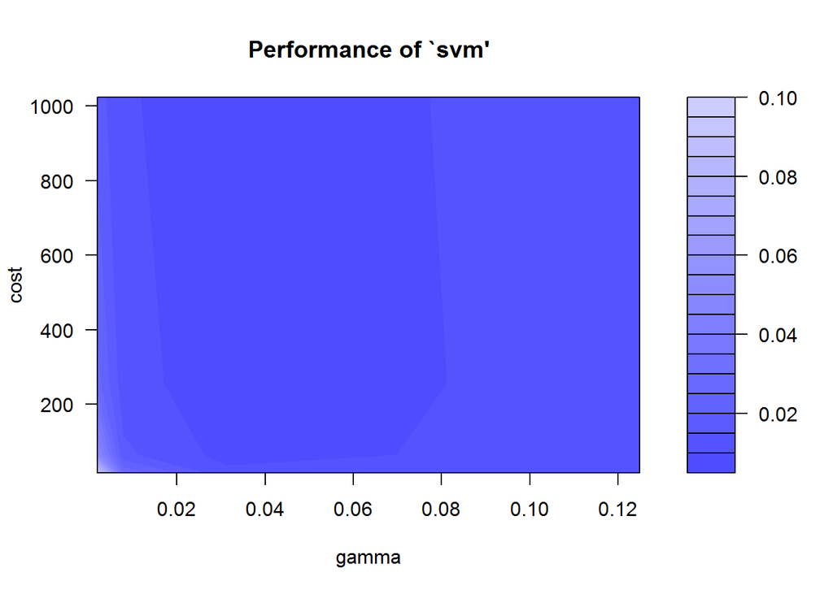

```r
plot(Model.TunedSVM)
```

```r
summary(Model.TunedSVM)
```

```
Parameter tuning of 'svm':

- sampling method: fixed training/validation set

- best parameters:
   gamma cost
 0.03125  256

- best performance: 0.007206814

- Detailed performance results:
         gamma cost       error dispersion
1  0.001953125   16 0.095217296         NA
2  0.007812500   16 0.029045643         NA
3  0.031250000   16 0.011137803         NA
4  0.125000000   16 0.012229744         NA
5  0.001953125   64 0.050666084         NA
6  0.007812500   64 0.016160734         NA
7  0.031250000   64 0.008298755         NA
8  0.125000000   64 0.012448133         NA
9  0.001953125  256 0.026643372         NA
10 0.007812500  256 0.011792968         NA
11 0.031250000  256 0.007206814         NA
12 0.125000000  256 0.012448133         NA
13 0.001953125 1024 0.017252675         NA
14 0.007812500 1024 0.010482638         NA
15 0.031250000 1024 0.007643590         NA
16 0.125000000 1024 0.012448133         NA
```

```r
BestTunedSVM <- Model.TunedSVM$best.model

mean(predict(BestTunedSVM, newdata = db.training) == db.training$classe)
```

```
[1] 1
```

```r
mean(predict(BestTunedSVM, newdata = db.validation) == db.validation$classe)
```

```
[1] 0.9949023
```

## 5.2 Random Forest

Here we fit a model with the Random Forest algorithm with the “randomForest()” function from the “randomForest” package. We use the default parameters, like the number of variables for each split (which in this case is $\sqrt{52}\approx 7$) and the number of trees, which is 500.

```r
set.seed(1234)

start_time <- proc.time()
ModRF <- randomForest(formula = classe~.,
                      data = db.training)
time1 <- proc.time() - start_time
time1
```

```
   user  system elapsed
  36.58    0.21   36.87
```

We see that the estimated “out of sample” (called also “out-of-bag” error, or OOB) error is 0.44%:

```r
print(ModRF)
```

```
Call:
 randomForest(formula = classe ~ ., data = db.training)
               Type of random forest: classification
                     Number of trees: 500
No. of variables tried at each split: 7

        OOB estimate of  error rate: 0.44%
Confusion matrix:
     A    B    C    D    E  class.error
A 3905    1    0    0    0 0.0002560164
B   12 2641    5    0    0 0.0063957863
C    0    9 2386    1    0 0.0041736227
D    0    0   23 2228    1 0.0106571936
E    0    0    1    8 2516 0.0035643564
```

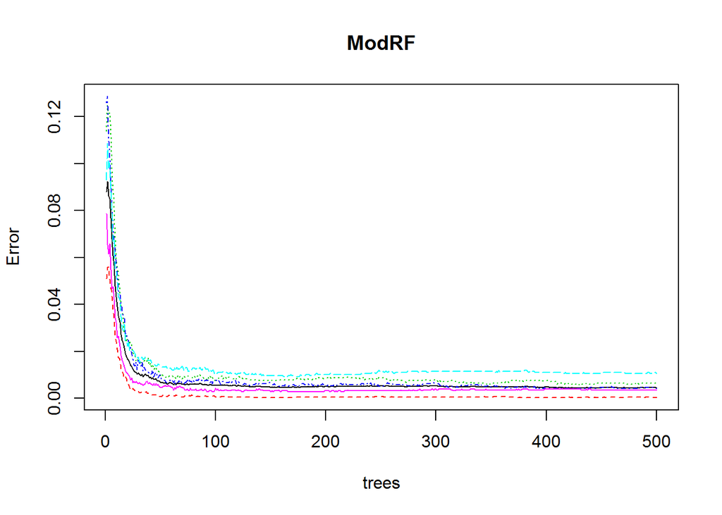

```r
plot(ModRF)
```

Below we test the accuracy on the training and the validation sets and we see that it is 100% and 99.52%, respectively, which is in agreement with the OOB estimate.

```r
mean(predict(ModRF, newdata = db.training) == db.training$classe)
```

```
[1] 1
```

```r
mean(predict(ModRF, newdata = db.validation) == db.validation$classe)
```

```
[1] 0.9952421
```

```r
set.seed(1234)

start_time <- proc.time()
ModRF.small <- randomForest(formula = classe~.,
                            data = db.training,
                            ntree = 100)
time2 <- proc.time() - start_time
time2
```

```
   user  system elapsed
   8.01    0.01    8.06
```

On our machine the computational time went from about 36.58s to 8.01s, which is about 4.6 times faster. From the code below, we see that the OOB error estimate increased a little bit to 0.55%. The accuracy is again 100% on the training data and it decreased by less than 0.2% on the validation set:

```r
print(ModRF.small)
```

```
Call:
 randomForest(formula = classe ~ ., data = db.training, ntree = 100)
               Type of random forest: classification
                     Number of trees: 100
No. of variables tried at each split: 7

        OOB estimate of  error rate: 0.55%
Confusion matrix:
     A    B    C    D    E  class.error
A 3904    1    0    0    1 0.0005120328
B   13 2637    8    0    0 0.0079006772
C    0   13 2377    6    0 0.0079298831
D    0    0   22 2229    1 0.0102131439
E    0    1    1    9 2514 0.0043564356
```

```r
mean(predict(ModRF.small, newdata = db.training) == db.training$classe)
```

```
[1] 1
```

```r
mean(predict(ModRF.small, newdata = db.validation) == db.validation$classe)
```

```
[1] 0.9937128
```

### 5.2.1 Notes

We also tried the “train()” function from the “caret” package. However, for this data set it was much more computationally expensive with its default settings and it did not give better results. Therefore, we provide only results for “svm()” and “randomForest()”. The given computational times are on a laptop with Intel i7 5500U CPU and 8GB DDR3-1600 RAM.

# 6 Predicting the outcomes of the test cases

We use the two fitted Random Forest models and the SVM model to predict the outcomes for the test data set:

```r
predict(BestTunedSVM, newdata = db.test)
```

```
##  1  2  3  4  5  6  7  8  9 10 11 12 13 14 15 16 17 18 19 20
##  B  A  B  A  A  E  D  B  A  A  B  C  B  A  E  E  A  B  B  B
## Levels: A B C D E
```

```r
predict(ModRF, newdata = db.test)
```

```
##  1  2  3  4  5  6  7  8  9 10 11 12 13 14 15 16 17 18 19 20
##  B  A  B  A  A  E  D  B  A  A  B  C  B  A  E  E  A  B  B  B
## Levels: A B C D E
```

```r
predict(ModRF.small, newdata = db.test)
```

```
##  1  2  3  4  5  6  7  8  9 10 11 12 13 14 15 16 17 18 19 20
##  B  A  B  A  A  E  D  B  A  A  B  C  B  A  E  E  A  B  B  B
## Levels: A B C D E
```

```r
sum(predict(BestTunedSVM, newdata = db.test) != predict(ModRF, newdata = db.test))
```

```
## [1] 0
```

```r
sum(predict(BestTunedSVM, newdata = db.test) != predict(ModRF.small, newdata = db.test))
```

```
## [1] 0
```